# Pond Mouse Data Analysis

Chris Hammill

September 18, 2017

In this document we will be performing a simple analysis of data from the POND Mouse Data Platform. In this example we will run a structural and voxel-wise linear models to compare wildtype and mutant mice.

## Unpacking the data

First thing we’ll need to do is unpack the data

```bash
## Unzip the main dir
unzip pond_data_download.zip -d pond_data_download
## Enter the extract dir
cd pond_data_download/
## Unzip each subject directory
for file in *.zip; do unzip $file; done
## Remove unnecessary leftover zips
rm *.zip
```

We can have a look around the export

```bash
ls
```

```
## PND31_HSC
## PND31_HSC_0001_01_SE01_MR
## PND31_HSC_0002_01_SE01_MR
## PND31_HSC_0003_01_SE01_MR
## PND31_HSC_0004_01_SE01_MR
## PND31_HSC_0005_01_SE01_MR
## PND31_HSC_0006_01_SE01_MR
## PND31_HSC_0007_01_SE01_MR
## PND31_HSC_0008_01_SE01_MR
## PND31_HSC_0009_01_SE01_MR
## PND31_HSC_0010_01_SE01_MR
## PND31_HSC_0011_01_SE01_MR
## PND31_HSC_0012_01_SE01_MR
## PND31_HSC_0013_01_SE01_MR
## PND31_HSC_0014_01_SE01_MR
## PND31_HSC_0015_01_SE01_MR
## PND31_HSC_0016_01_SE01_MR
## PND31_HSC_0017_01_SE01_MR
## PND31_HSC_0018_01_SE01_MR
## PND31_HSC_0019_01_SE01_MR
## PND31_HSC_0020_01_SE01_MR
## tabledata_3b3b810f-634b-4eca-889c-c56d22087d79.csv
```

Here we see there is a set of directories ending in `_MR`, these are our subject directories. There is also a file beginning with `tabledata`, this is our metadata for the export. There is also a directory `PND31_HSC`, this contains files relevant to the whole study.

## Getting Metadata into R

First we’re going to need to get R up and running and tell it where to find all the files we want to analyze. Open up an R session and do the following:

```r
options(stringsAsFactors = FALSE)

metadata_file <- Sys.glob("tabledata*")
metadata <- read.csv(metadata_file)

average_file <-
  "PND31_HSC/resources/Study_Average/files/img_09aug12.16.jan2011_distortion_corrected-nlin-3.mnc"

names(metadata)[1:10]
```

```
##  [1] "Mouse_ID"              "POND_Mouse_ID"
##  [3] "Study_Name"            "Is_Wildtype"
##  [5] "Genotype"              "MGI_Genotype"
##  [7] "Background"            "MGI_Background"
##  [9] "Treatment_Code"        "Treatment_Description"
```

```r
names(metadata)[361:371]
```

```
##  [1] "left_Olfactory_bulb_mitral_cell_layer"
##  [2] "left_Olfactory_bulb_internal_plexiform_layer"
##  [3] "left_Olfactory_bulb_granule_cell_layer"
##  [4] "left_Accessory_olfactory_bulb_glomerular_external_plexiform_and_mitral_cell_layer"
##  [5] "left_Accessory_olfactory_bulb_granule_cell_layer"
##  [6] "left_Anterior_olfactory_nucleus"
##  [7] "right_Medial_amygdala"
##  [8] "right_Medial_preoptic_nucleus"
##  [9] "left_Medial_amygdala"
## [10] "left_Medial_preoptic_nucleus"
## [11] "Total_brain_volume"
```

Presented above are the first 10, and last ten column names. Of all the columns the first 34 represent important metadata, the rest represent structure volumes. We’re going divide these two, and remove the last column (total brain volume).

```r
structure_vols <- metadata[, -c(1:34, 371)]
metadata <- metadata[, 1:34]
metadata$Is_Wildtype <- factor(metadata$Is_Wildtype, levels = c("WT", "MUT"))
```

## Basic Structure-wise Analysis

The main goal of this study is to examine where in the brain there is an effect of an Fmr1 mutation on brain volume. For structure-wise analysis, you first need a set of subject specific labels indicating which regions of the brain are which. The paradigm we use to generate these labels is called MAGeT (Multiple Automatically Generated Templates). Once these labels have been generated you can sum the voxel volumes associated with each label to determine the volume of each structure. We have performed this first step for you.

In this example, We will be using the `RMINC` library to compute the a linear model at each structure models. To learn more about `RMINC` visit https://github.com/Mouse-Imaging-Centre/RMINC. `RMINC` has created fast versions of R’s `lm` function, including one for fitting a linear model at each structure. The syntax is almost identical to a standard R linear model.

To fit a simple linear model (essentially a t-test) to each structure we can do the following:

```r
anat_mod <- anatLm(~ Is_Wildtype, data = metadata, anat = structure_vols)
```

```
## N: 20 P: 2
## Beginning vertex loop: 336 3
## Done with vertex loop
```

You will notice there is no left-hand-side to the formula, this is because each column of the `anat` argument is taken to be the response variable in turn. For more details consult `RMINC`’s extensive help documentation with R’s standard `?<function>`, for example `?anatLm`.

The object produced is essentially an R matrix, with each column indicating a relevant component of the model fit, and each row representing a structure.

```r
colnames(anat_mod)
```

```
## [1] "F-statistic"           "R-squared"             "beta-(Intercept)"
## [4] "beta-Is_WildtypeMUT"   "tvalue-(Intercept)"    "tvalue-Is_WildtypeMUT"
## [7] "logLik"
```

You can see that it produces an F-statistic for the overall model, an $R^2$, beta (estimate) and tvalue (statistic) for each predictor, as well as the log likelihood of the data given the fitted model.

To control for the fact we have performed many tests, we typically limit the false-discovery rate, or the proportion of tests we reject that were in fact null. To do this we can use `anatFDR`

```r
anat_fdr <- anatFDR(anat_mod)
```

```
##
## Computing FDR threshold for all columns
##   Computing threshold for  F-statistic
##   Computing threshold for  tvalue-(Intercept)
##   Computing threshold for  tvalue-Is_WildtypeMUT
```

```r
anat_fdr
```

```
## Multidimensional MINC volume
## Columns:       F-statistic tvalue-(Intercept) tvalue-Is_WildtypeMUT
## NULL
## Degrees of Freedom: c(1, 18) 18 18
## FDR Thresholds:
##      F-statistic tvalue-(Intercept) tvalue-Is_WildtypeMUT
## 0.01   37.250000           8.520563                    NA
## 0.05   15.517241           8.520563                    NA
## 0.1     7.763781           8.520563              2.863899
## 0.15    6.152542           8.520563              2.501907
## 0.2     5.070000           8.520563              2.251666
```

By default the FDR results when printed show a convenient table of showing thresholds to control FDR at a given level. In this example to acheive an expected false discovery rate of 10% we should reject any test for the effect of being a having a mutation in Fmr1 is with an absolute t-statistic greater than 2.864.

## Basic Voxel-wise Analysis

Often we want to look for effects at a finer granularity than the structure volumes. The paradigm we use to accomplish this is called Deformation based morphometry (DBM), which assigns a volume change to each voxel in the brain. In this approach each mouse is registered to an average brain, this generates a set of deformation vectors indicating voxel correspondance and displacement between the mouse and the average. The determinant of the displacement vector (jacobian determinant) indicates the amount of volume change required to create the observed displacement. This gives a volume difference between the mouse and the average at each voxel. To analyze these volume differences, we can fit a linear model at each voxel in the brain and assess the effect of the mutation. Here the speed of `RMINC` starts to matter.

The command used is `mincLm` instead of `lm`, and the left-hand side of the model formula indicates a column of filenames, the right-hand side indicates the predictor variables.

```r
model <-
  mincLm(Scan_To_Study_Absolute_Jacobians_Path ~ Is_Wildtype
       , data = metadata)
```

```
## Method: lm
## Number of volumes: 20
## Volume sizes: 172 340 225
## N: 20 P: 2
## In slice
##  0  1  2  3  4  5  6  7  8  9  10  11  12  13  14  15  16  17  18  19  20  21  22  23  24  25  26  27  28  29  30  31  32  33  34  35  36  37  38  39  40  41  42  43  44  45  46  47  48  49  50  51  52  53  54  55  56  57  58  59  60  61  62  63  64  65  66  67  68  69  70  71  72  73  74  75  76…
## Done
```

You can fit more complicated models by elaborating on the formula.

You’ll note that the columns of the `mincLm` model are identical to those of the structural model above, but in this case there is a row for every voxel.

As above we can control our false-discovery rate

```r
minc_fdr <- mincFDR(model)
```

```
##
## Computing FDR threshold for all columns
##   Computing threshold for  F-statistic
##   Computing threshold for  tvalue-(Intercept)
##   Computing threshold for  tvalue-Is_WildtypeMUT
```

```r
minc_fdr
```

```
## Multidimensional MINC volume
## Columns:       F-statistic tvalue-(Intercept) tvalue-Is_WildtypeMUT
## [1] "PND31_HSC_0001_01_SE01_MR/scans/MR_MINC-mice_ex_vivo_fixedbrain_56um/resources/Scan_To_Study_Absolute_Jacobians/files/img_09aug12.16.jan2011_distortion_corrected-final-nlin_with_additional_inverted_absolute_log_determinant_fwhm0.2.mnc"
## Degrees of Freedom: c(1, 18) 18 18
## FDR Thresholds:
##      F-statistic tvalue-(Intercept) tvalue-Is_WildtypeMUT
## 0.01    47.62525           5.697049              6.901105
## 0.05    22.09724           4.405071              4.700770
## 0.1     13.42732           3.792609              3.664331
## 0.15    10.05764           3.413750              3.171378
## 0.2      8.17576           3.136314              2.859329
```

Here we can see that we could find significant results for the effect of mutation even controlling our FDR at 1%.

This isn’t the end of the story. The column we used for the above analysis `Scan_To_Study_Absolute_Jacobians` represents the total deformation required to map between brains, often you want to move the effect of the overall brain size. To do this, you can use `Scan_To_Study_Relative_Jacobians`, this gives the deformation required to map between brains after scaling, rotating, and sheering the brains to get a linear match.

To visualize the results, `RMINC` provides plotting commands

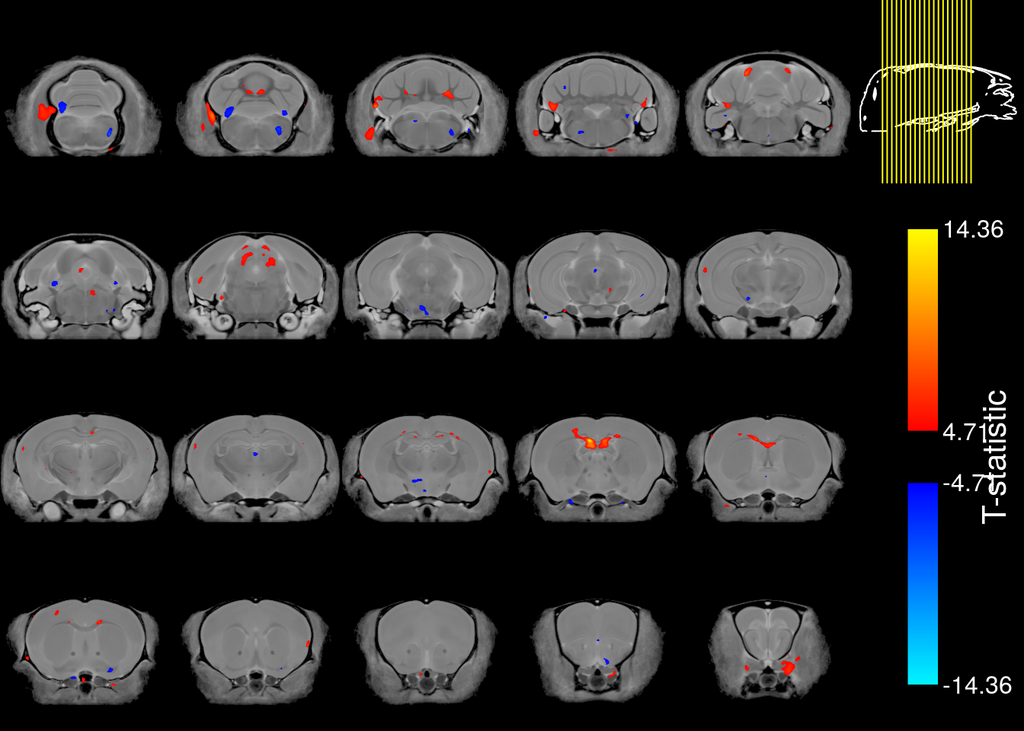

```r
min_value <- ceiling( thresholds(minc_fdr)["0.05", "tvalue-Is_WildtypeMUT"] * 100) / 100
max_value <- ceiling( max(abs(model[,"tvalue-Is_WildtypeMUT"]) * 100)) / 100

mincPlotSliceSeries(
  mincArray(mincGetVolume(average_file))
, mincArray(model,  "tvalue-Is_WildtypeMUT")
, low = min_value
, high = max_value
, begin = 50
, end = -100
, symmetric = TRUE
, legend = "T-statistic"
)
```

Here we see the strongest volume change in the ventricals, illustrated with the bright yellow colour toward the right of the third row. For more details on the arguments to mincPlotSliceSeries call `?mincPlotSliceSeries`. Another useful way to explore the data is with our shiny applet, see `launch_shinyRMINC` for details.

## Outro

Here we’ve demonstrated just a few of the things you can do with a data set from the POND data download portal. These data and the tools offer many more interesting avenues to explore.